# Airbnb en Euskadi

montera34

April 12, 2017

# Airbnb en Euskadi

Airbnb en Euskadi, según los datos obtenidos por InsideAirbnb, contiene 2902 anuncios en 266 municipios, de ellos 395 tienen licencia de alojamiento turístico (13.6%).

En las capitales tenemos:

- **Donostia - San Sebastián** 1219 anuncios (42.0 % del total), de esos alojamientos tienen licencia 160 (13.1 % del municipio). Dispone de 4553 plazas. Anfitriones con alojamiento listado 696.
- **Bilbao** 457 (15.7% del total), de esos alojamientos tienen licencia 74 (16.2 % del municipio). Dispone de 1480 plazas. Anfitriones con alojamiento listado 365.
- **Vitoria - Gasteiz** 114 (3.9% del total), de esos alojamientos tienen licencia 0 (0.0 % del municipio). Dispone de 396 plazas. Anfitriones con alojamiento listado 86.

Por comparar con otras ciudades, el porcentaje de alojamientos con licencia turística en Barcelona es 18.0% de un total de 17369 alojamientos según datos de insideairbnb. Madrid (7446 alojamientos) y Mallorca (11271 alojamientos) no tienen indicado si tienen licencia.

# Efecto Airbnb en Bilbao

En Bilbao existen 365 anfitriones con alojamientos disponibles en Airbnb.

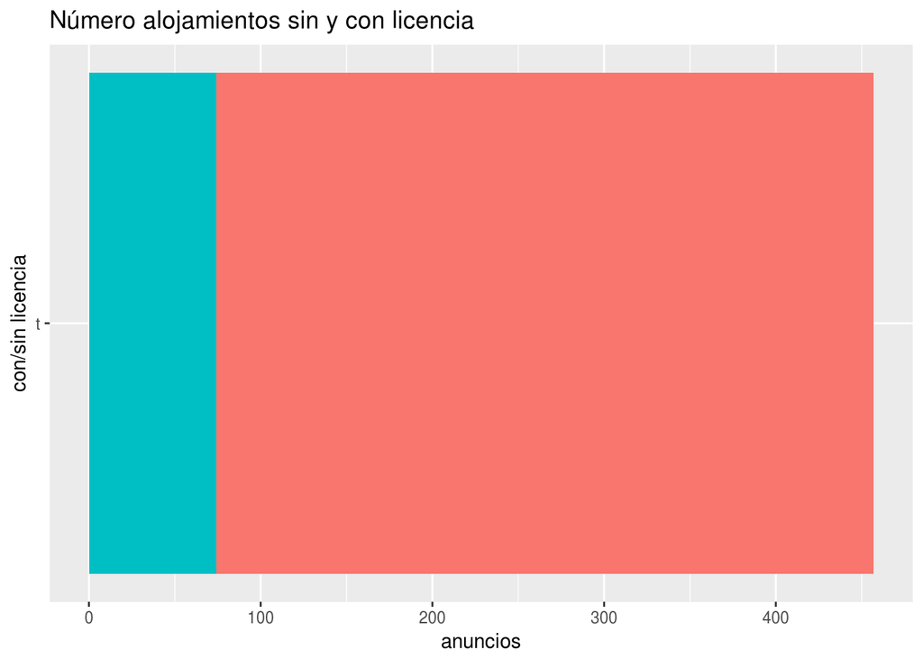

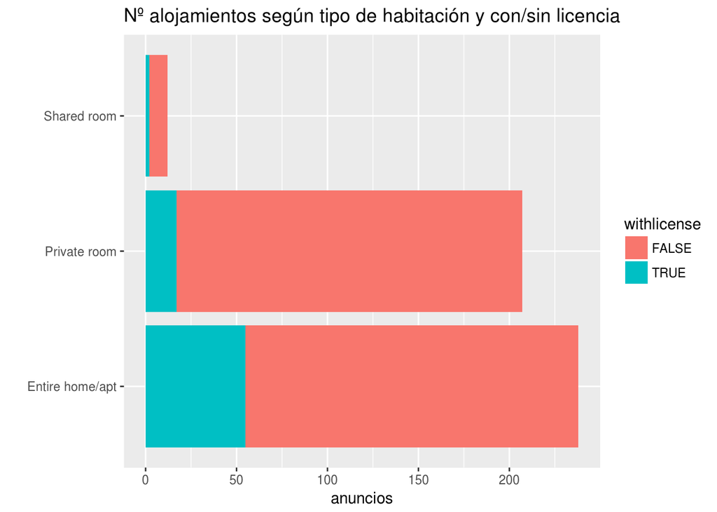

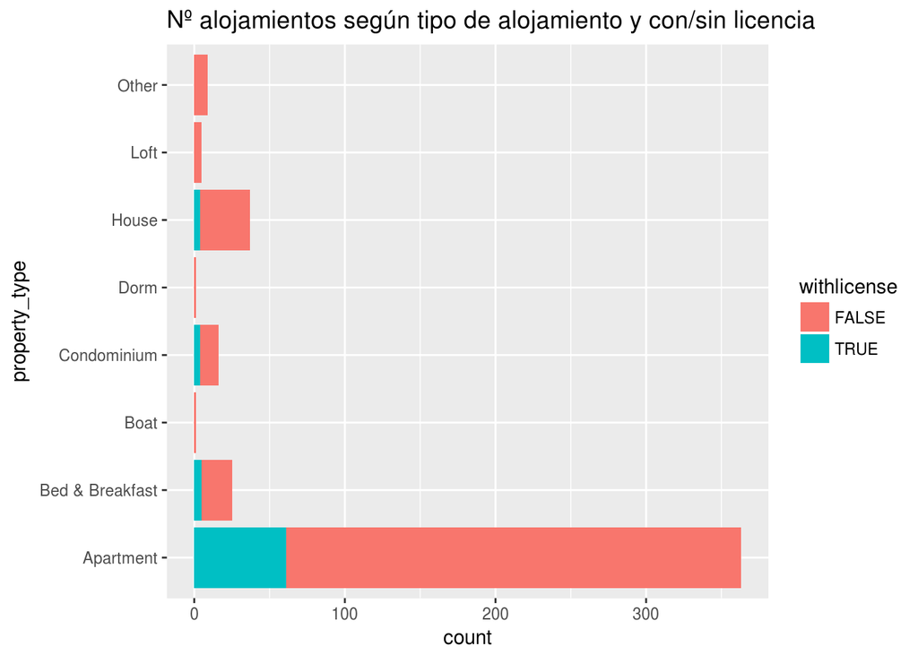

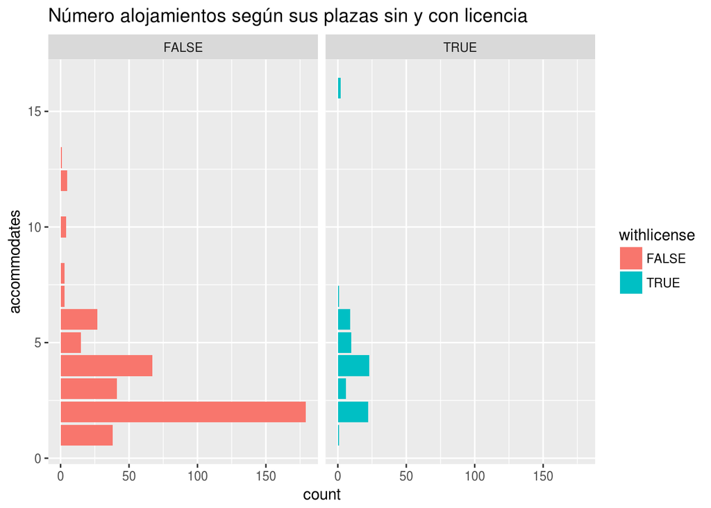

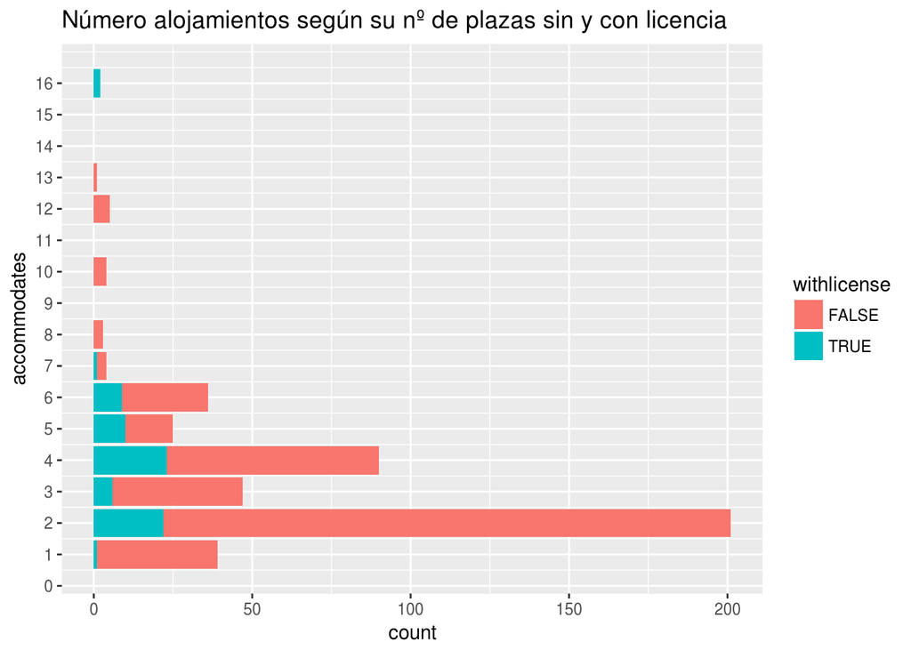

## Anfitriones en Airbnb

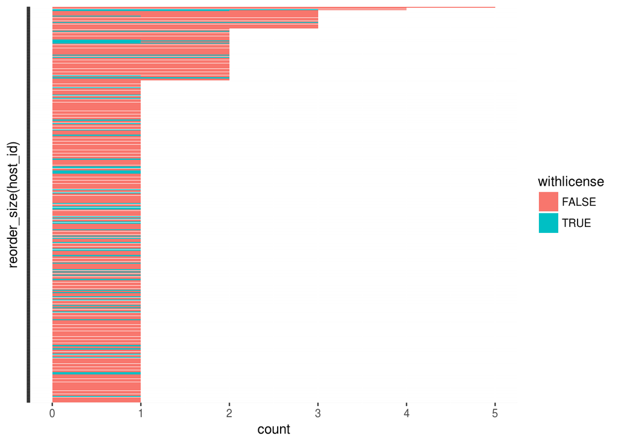

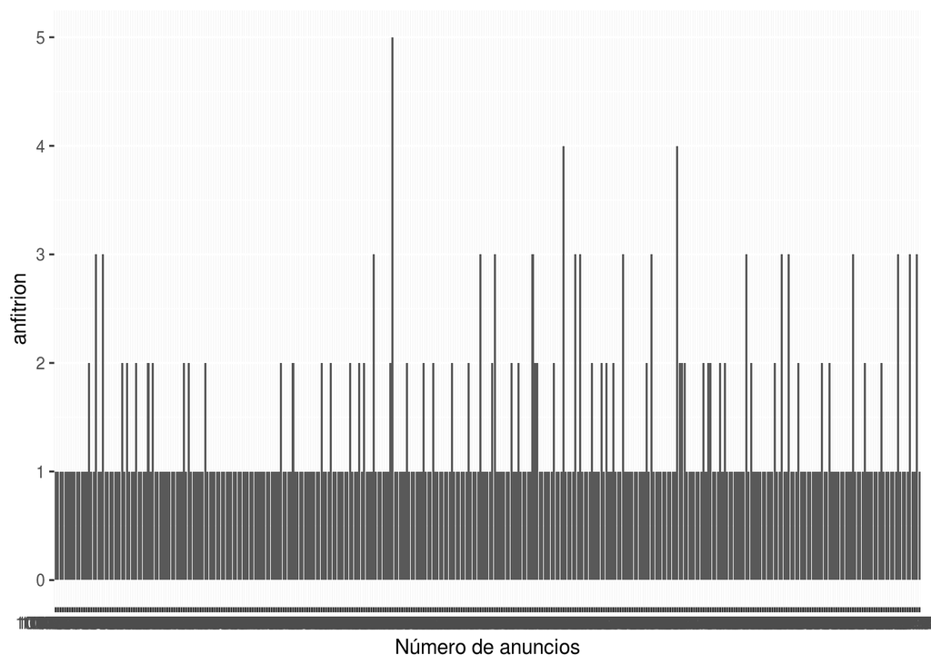

### Los anfitriones con más alojamientos

Los 20 anfitriones con más alojamientos (id)

| host_id | alojamientos |
| --- | --- |
| 35224923 | 5 |
| 499476 | 4 |
| 64771273 | 4 |
| 59550 | 3 |
| 4743615 | 3 |
| 7513964 | 3 |
| 7894654 | 3 |
| 8815867 | 3 |
| 9683730 | 3 |
| 33293247 | 3 |
| 42196465 | 3 |
| 43324450 | 3 |
| 51010157 | 3 |
| 51383826 | 3 |
| 56071673 | 3 |
| 79862959 | 3 |
| 94418214 | 3 |
| 97970926 | 3 |
| 107665484 | 3 |
| 108678187 | 3 |

### Los anfitriones con más plazas

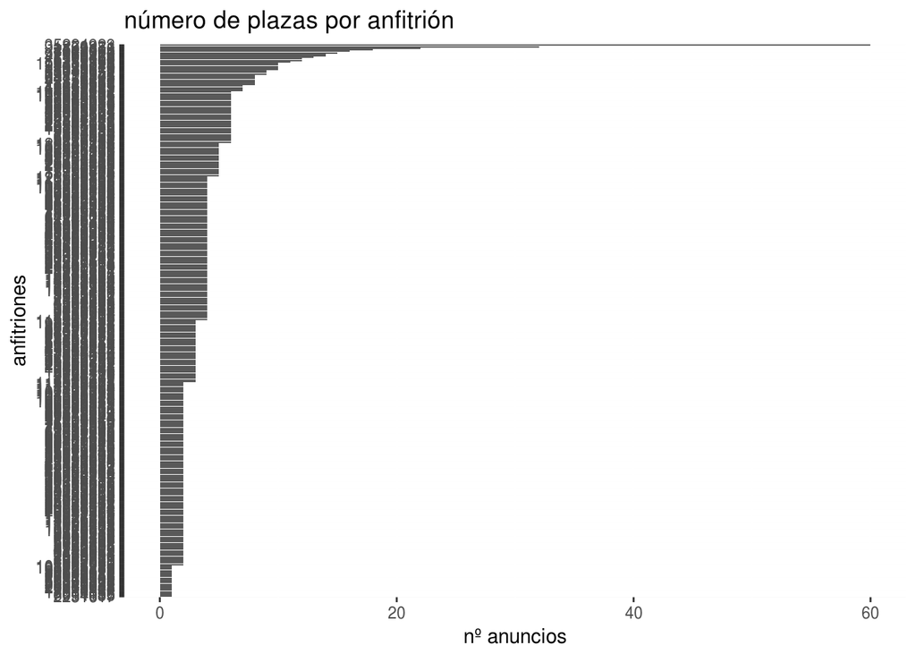

Los 10 primeros anfitriones (2.7% del total de anfitriones) con más plazas tienen 216 plazas disponibles (que son el 14.6% del total de plazas).

Los 20 primeros anfitriones (5.5% del total de anfitriones) con más plazas tienen 316 plazas disponibles (que son el 21.4% del total de plazas).

Los 50 primeros anfitriones (13.7% del total de anfitriones) con más plazas tienen 514 plazas disponibles (que son el 34.7% del total de plazas).

Los 100 primeros anfitriones (27.4% del total de anfitriones) con más plazas tienen 766 plazas disponibles (que son el 51.8% del total de plazas).

| host_id | plazas |
| --- | --- |
| 35224923 | 60 |
| 91853881 | 32 |
| 499476 | 22 |
| 4743615 | 18 |
| 7513964 | 16 |
| 7088275 | 15 |
| 42196465 | 14 |
| 97970926 | 14 |
| 8105454 | 13 |
| 5259162 | 12 |
| 6510178 | 12 |
| 51383826 | 11 |
| 15531075 | 10 |
| 17929578 | 10 |
| 53835119 | 10 |
| 94418214 | 10 |
| 115453825 | 10 |
| 33293247 | 9 |
| 51010157 | 9 |
| 65042652 | 9 |
| 1443597 | 8 |
| 7129633 | 8 |
| 8815867 | 8 |
| 47359313 | 8 |
| 54118293 | 8 |
| 64771273 | 8 |
| 69172345 | 8 |
| 4388051 | 7 |
| 12087842 | 7 |
| 40853483 | 7 |

### Número de reviews por cada alojamiento

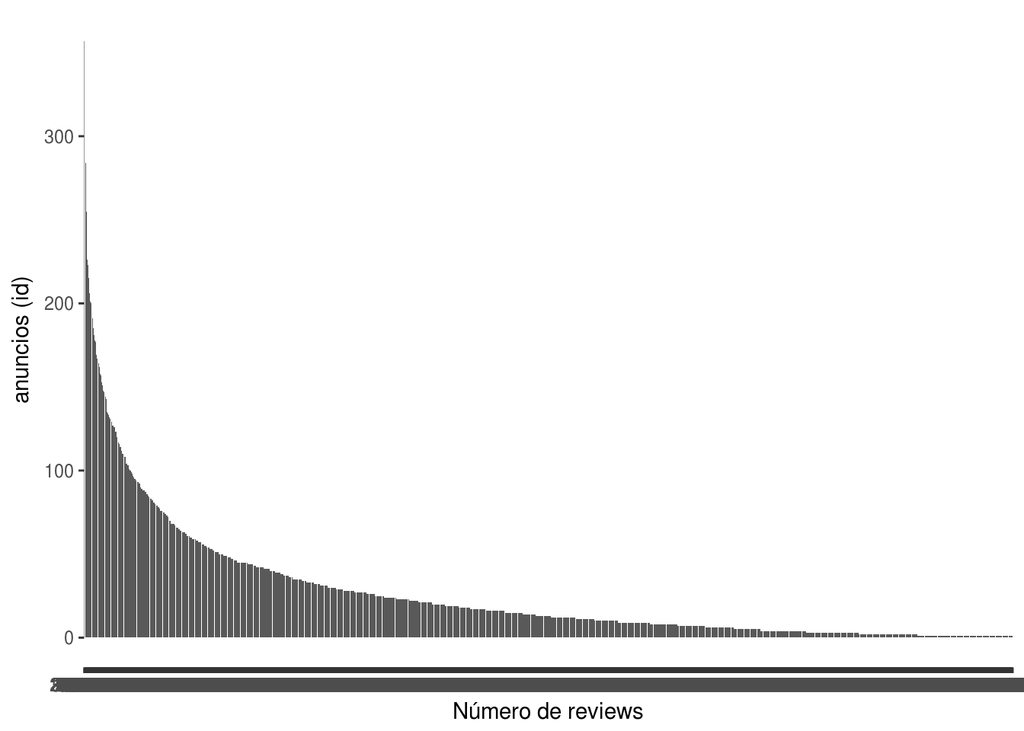

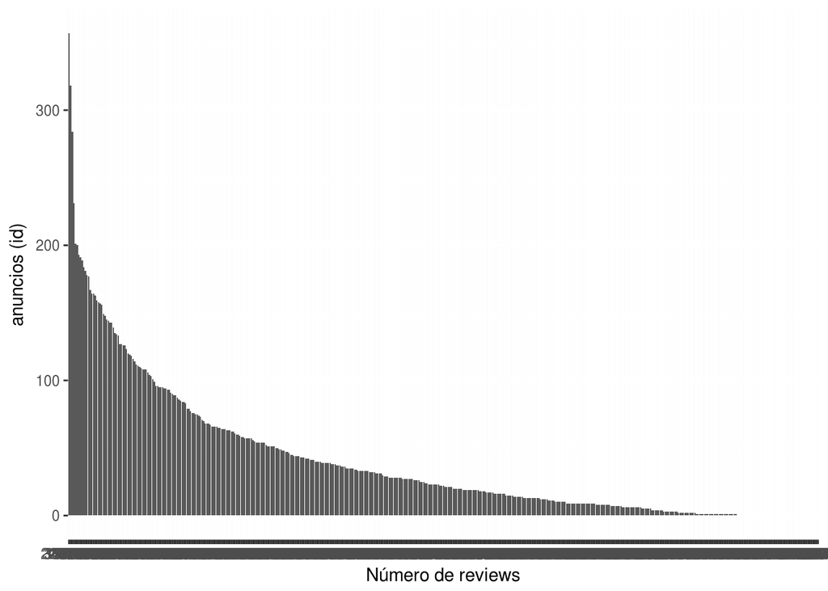

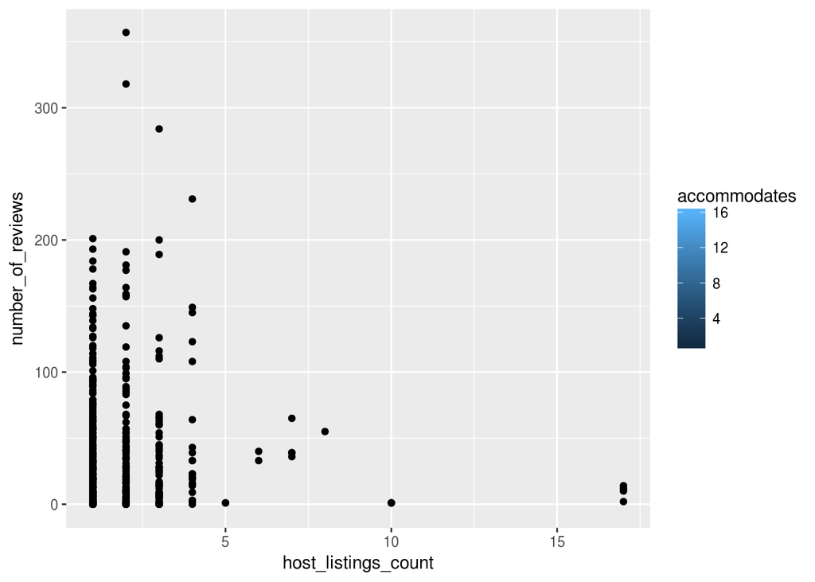

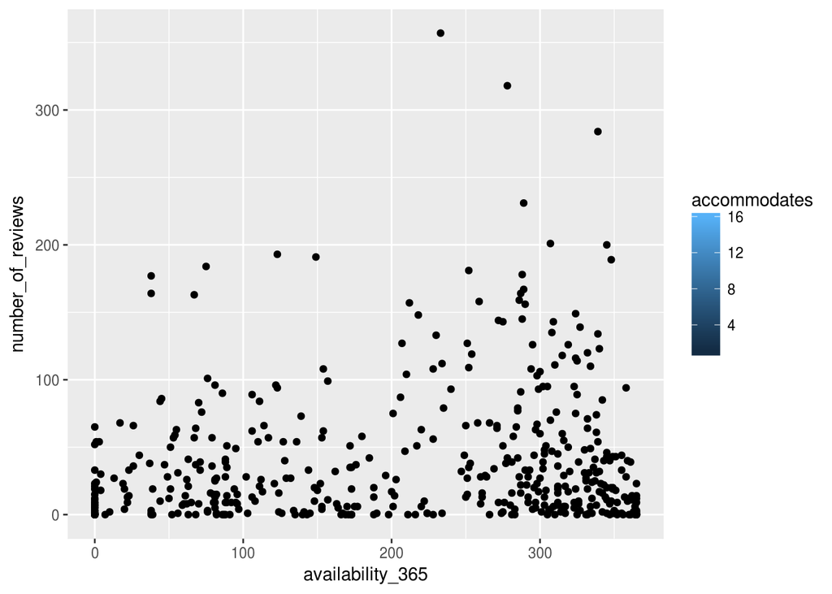

### Precio por noche

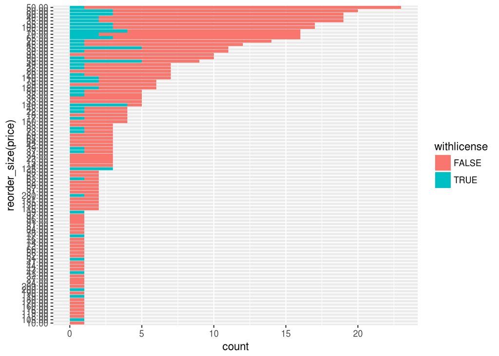

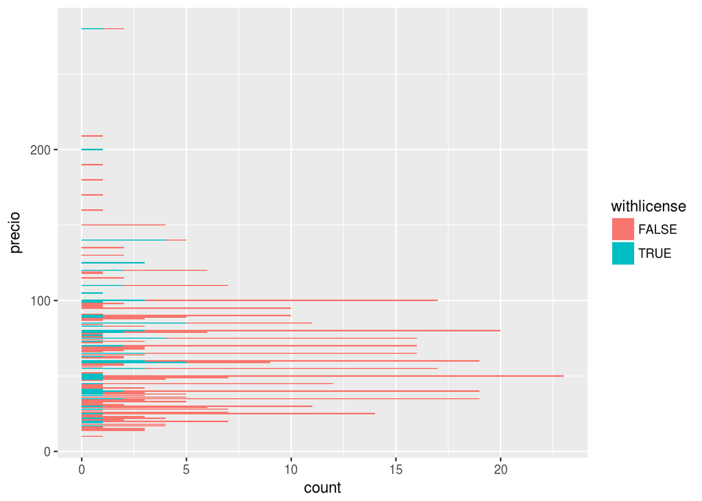

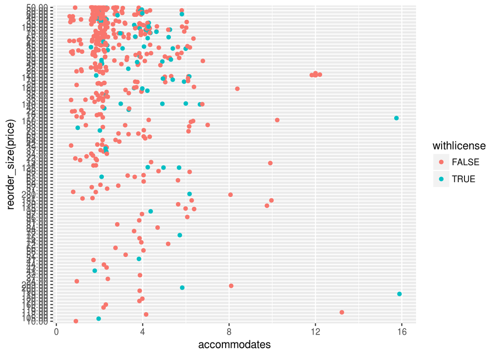

## Otros

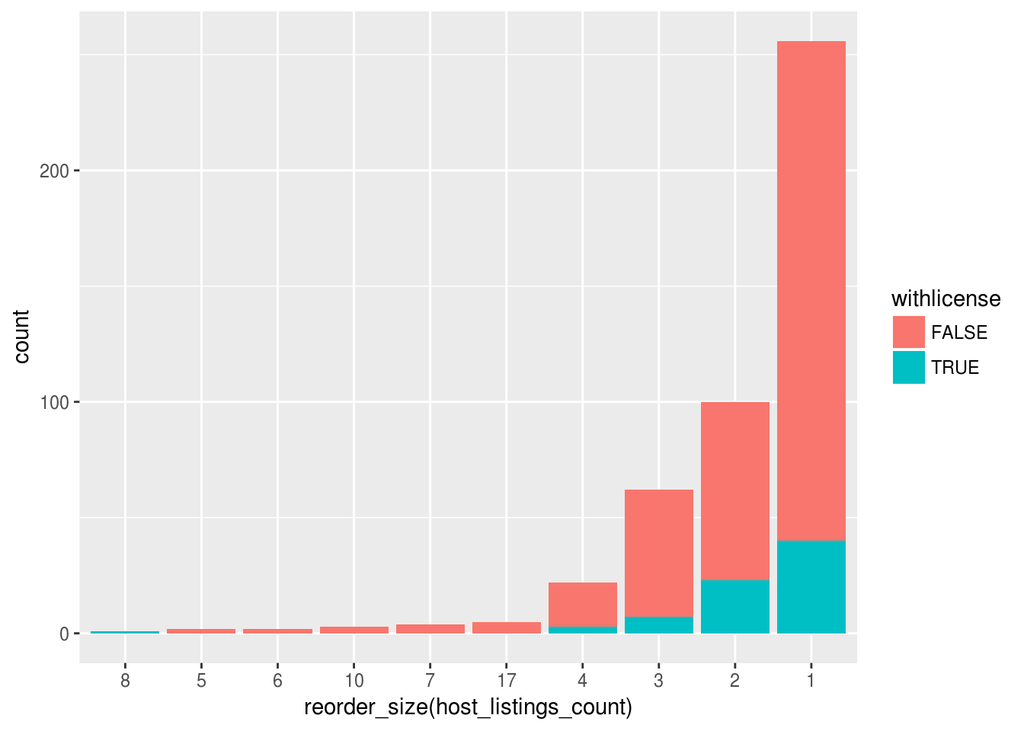

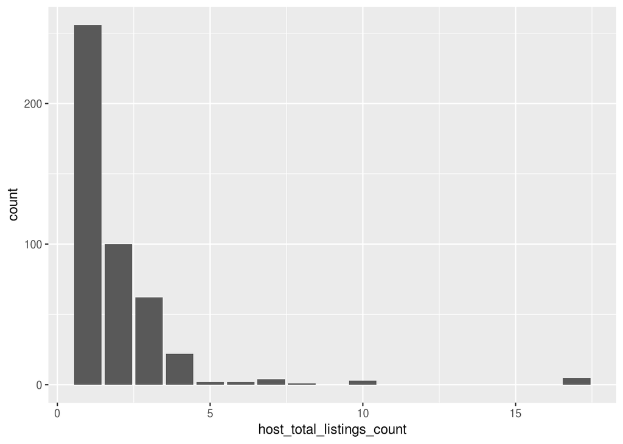

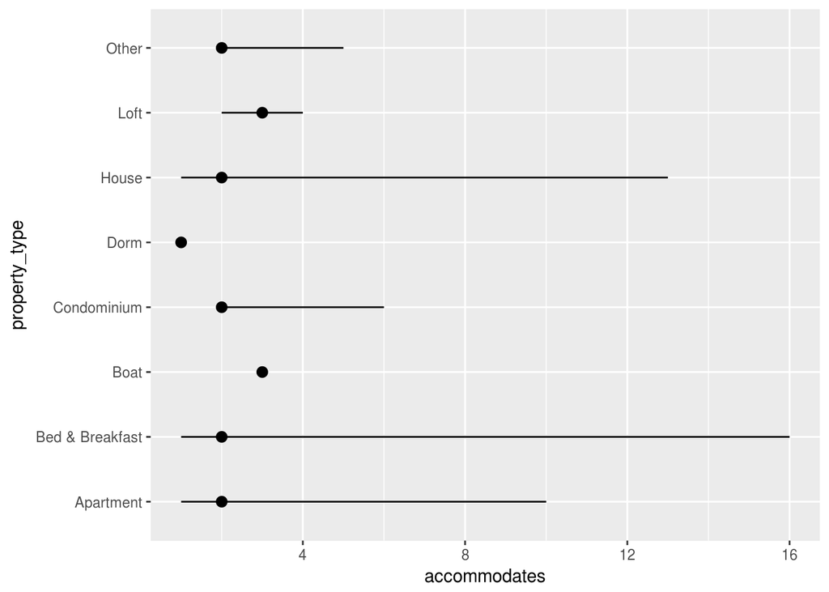

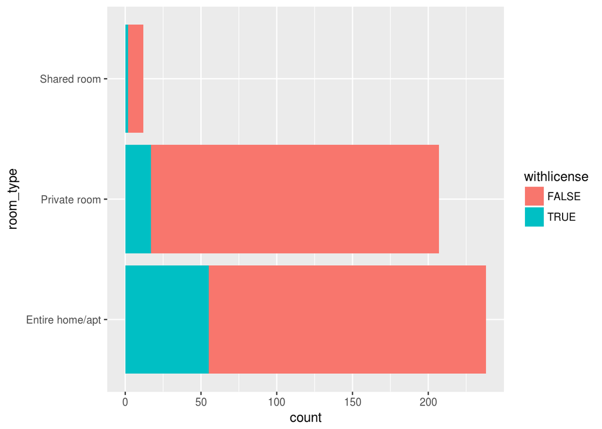

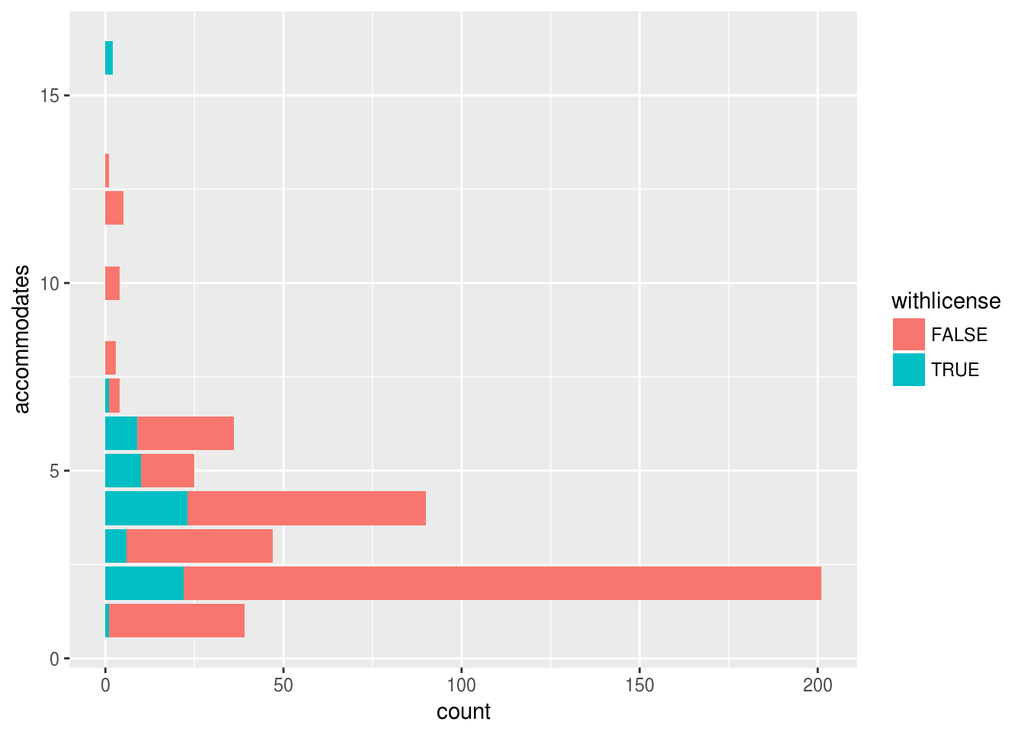

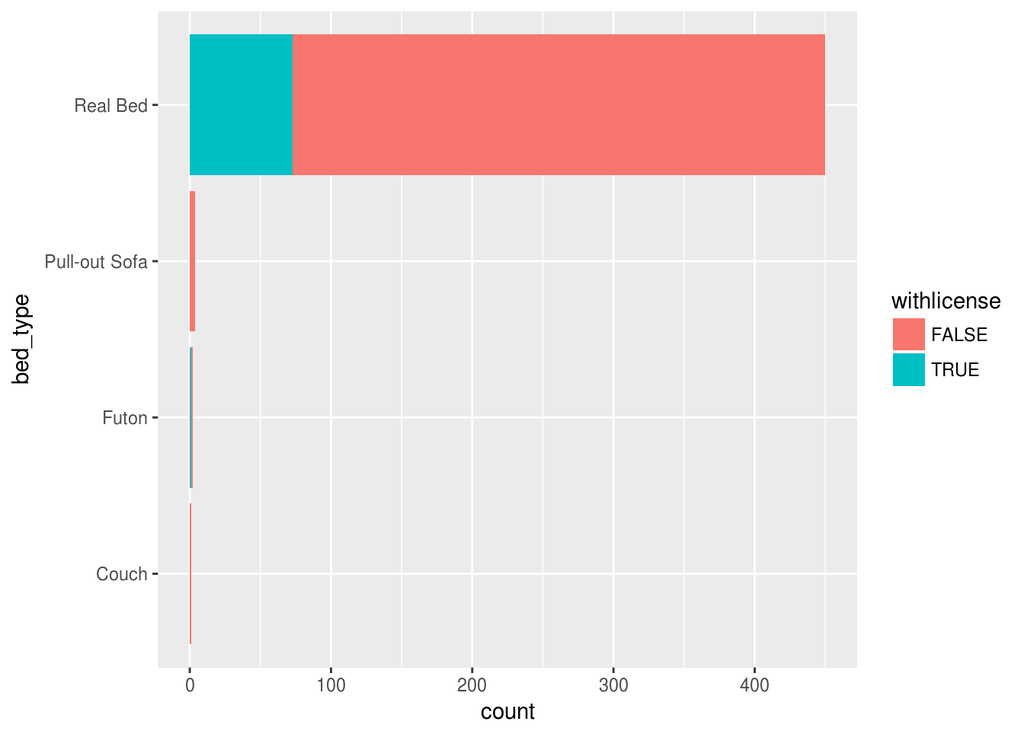

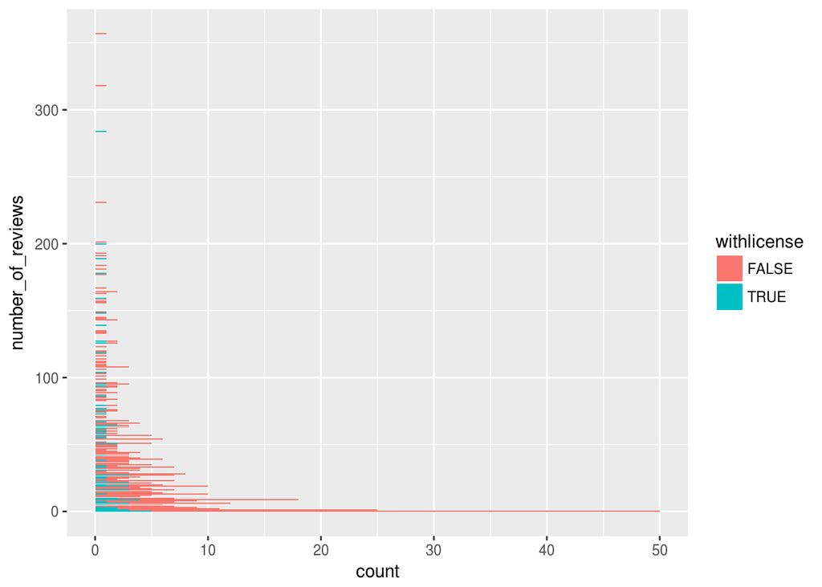

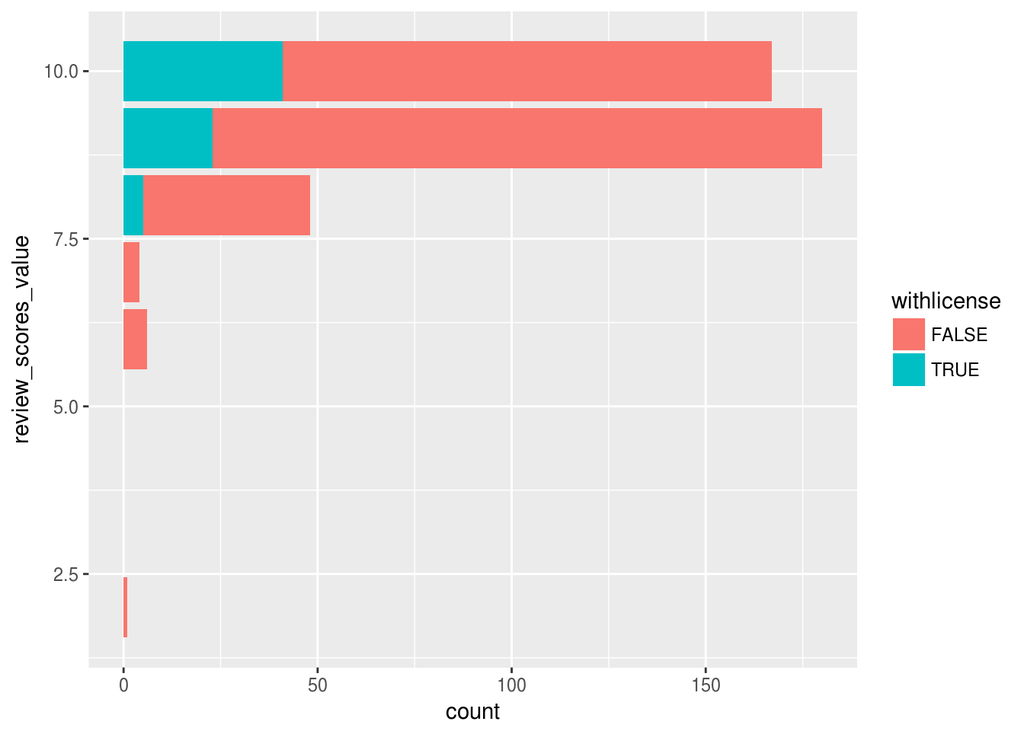

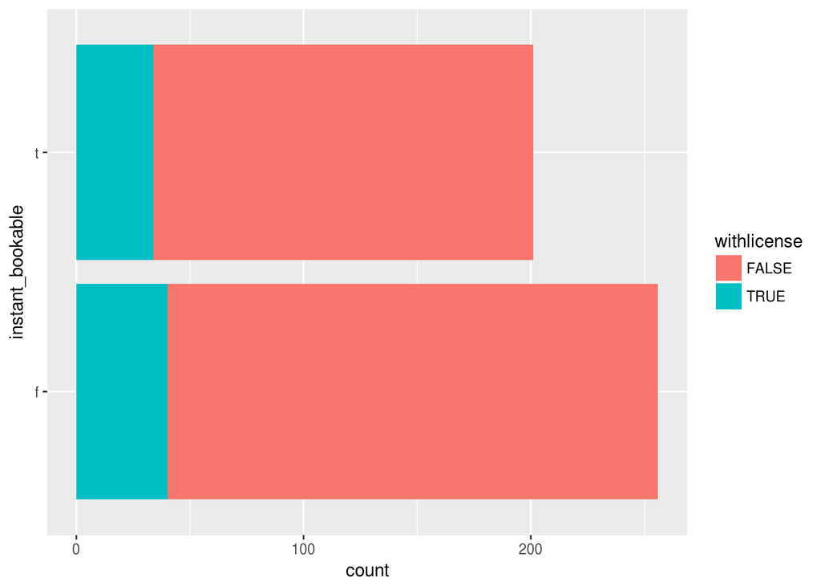

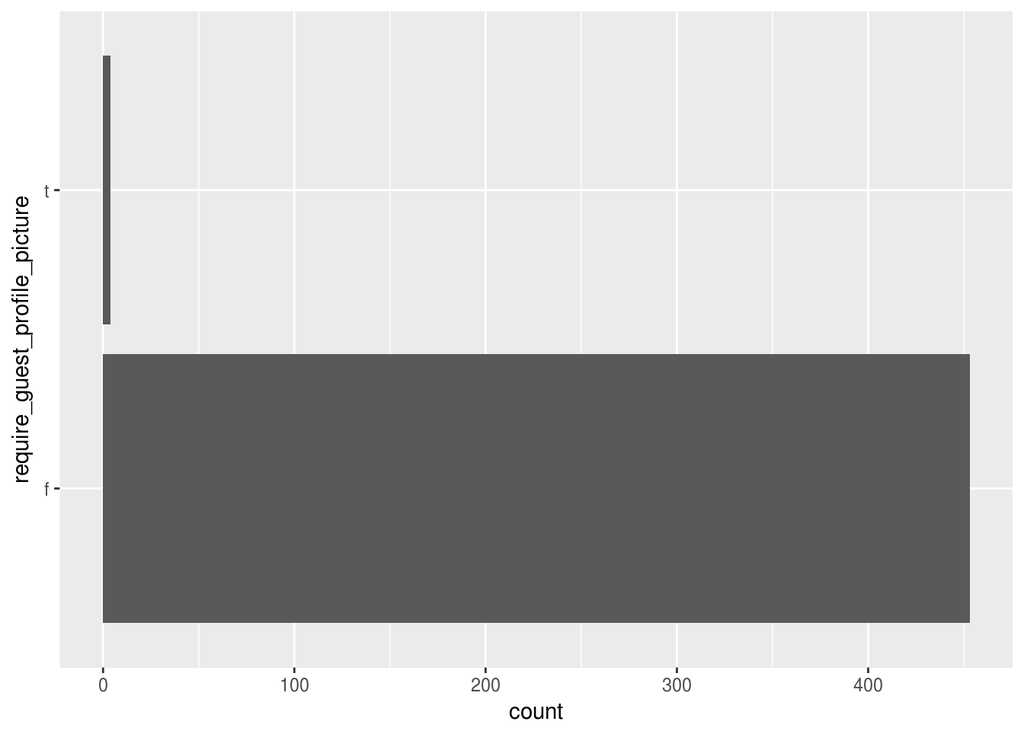

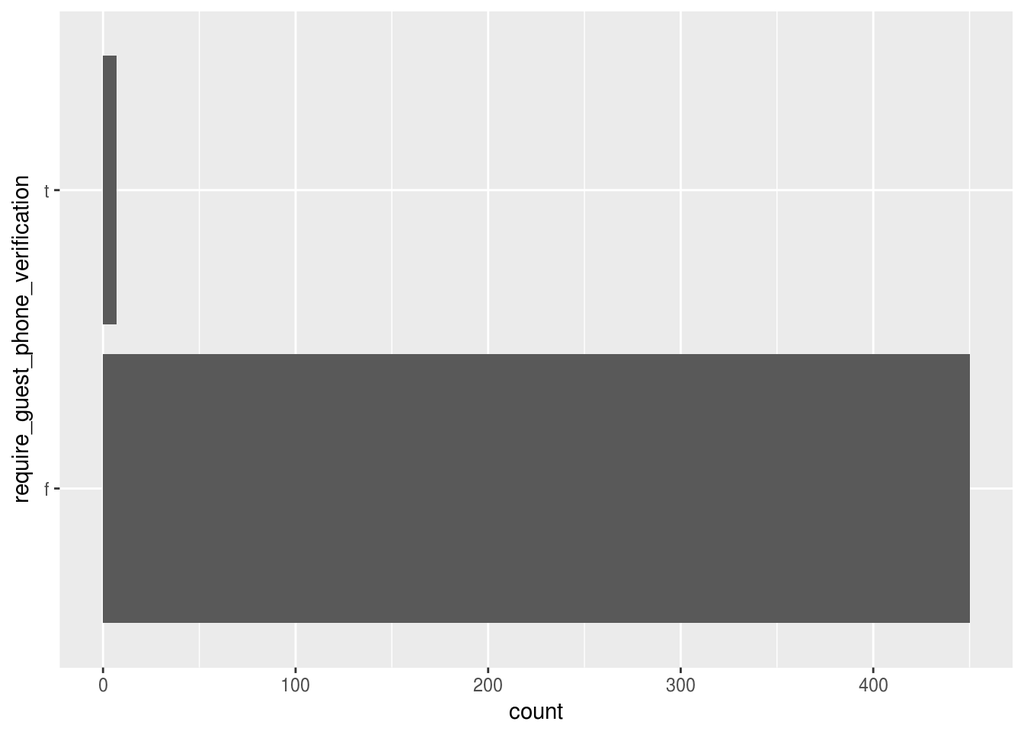

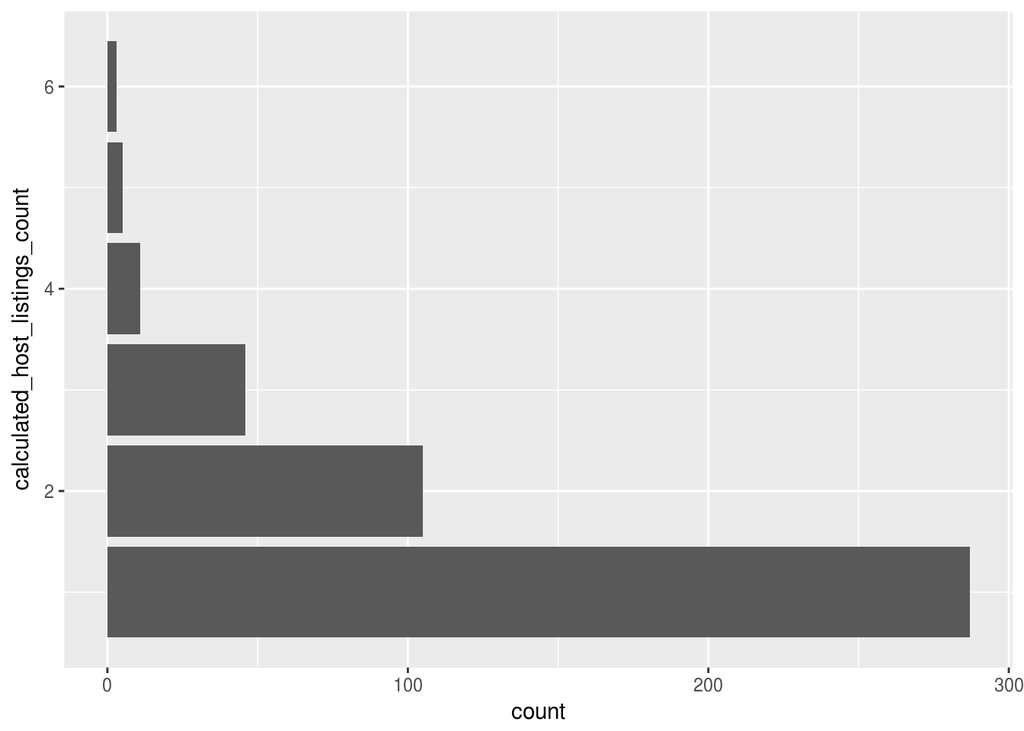

[6 more figures not shown]

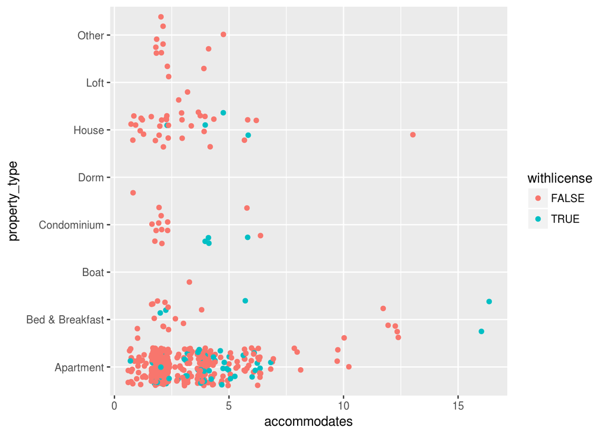

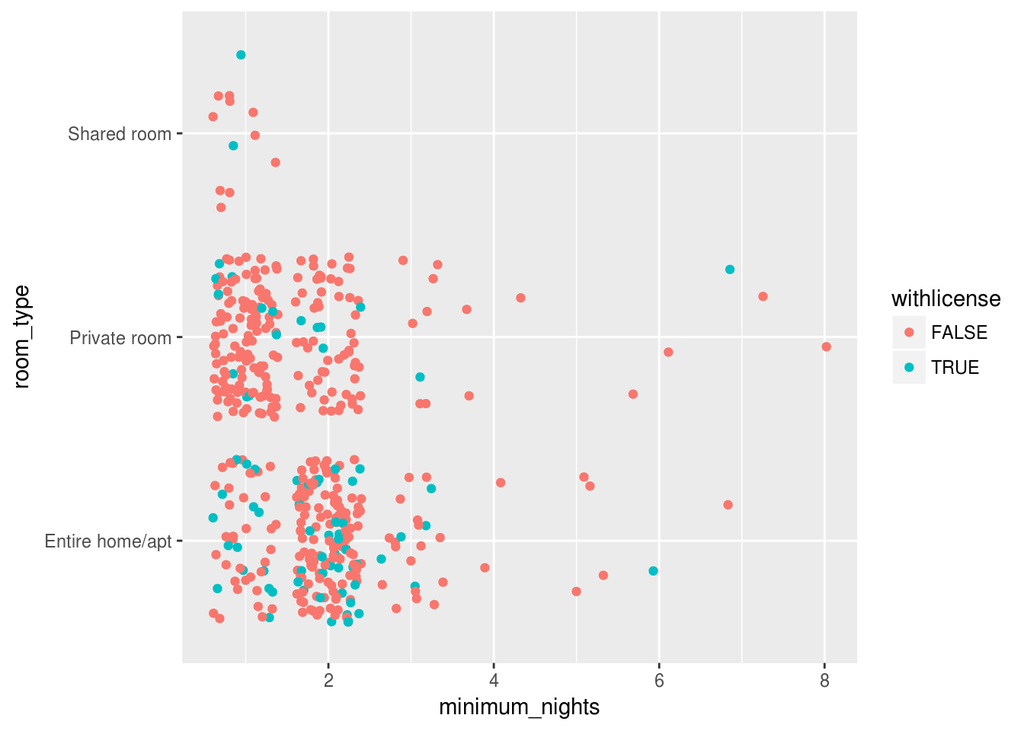

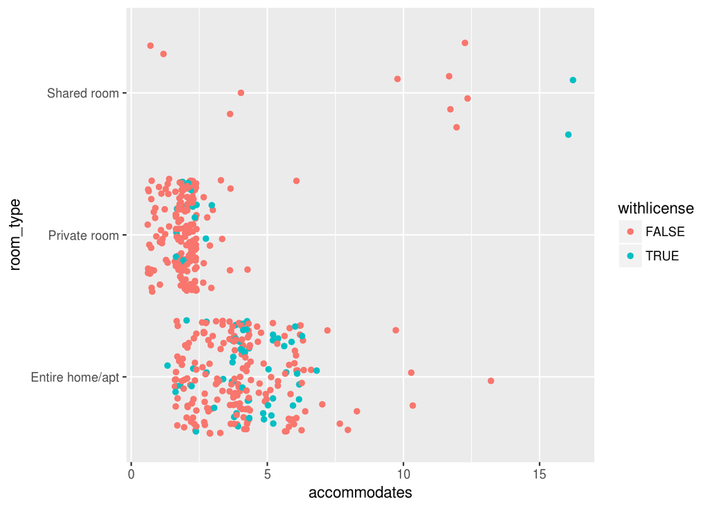